# Regional Analysis

Olivia

9/8/2020

# Analysis for Chicago Midway

#### Below is overall maximum temperatures in degrees celsius, measured by this airport station.

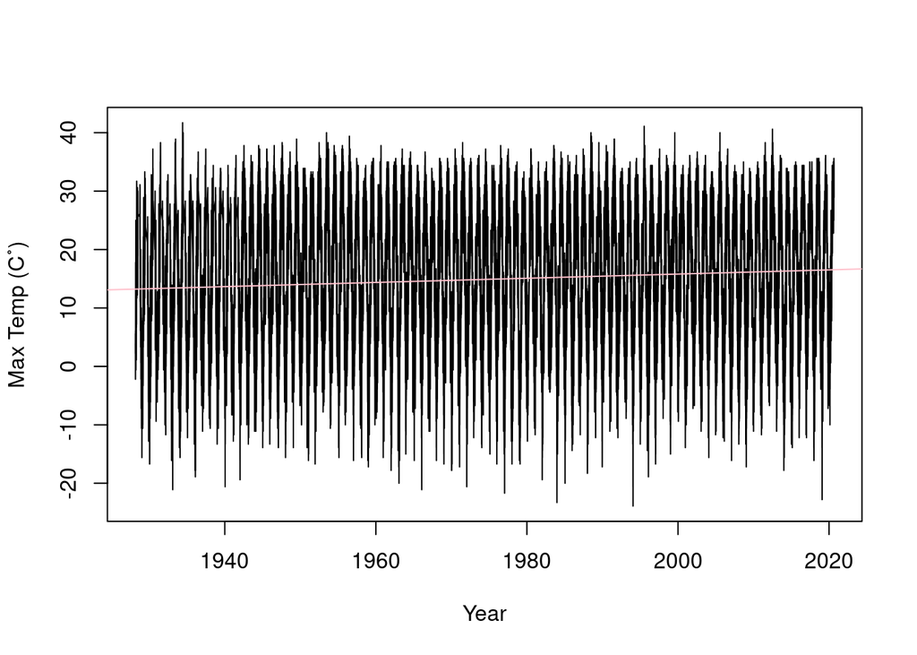

```r
plot(TMAX~NewDate, data=climate_data, ty='l', xlab='Year', ylab='Max Temp (C˚)')
TMAX.lm = lm(TMAX ~ NewDate, data=climate_data)
slopeintercept = coef(TMAX.lm)
abline(coef(TMAX.lm), col = 'pink')
```

```r
lm(TMAX ~ NewDate, data=climate_data)
```

```
##
## Call:
## lm(formula = TMAX ~ NewDate, data = climate_data)
##
## Coefficients:
## (Intercept)      NewDate
##   1.473e+01    9.811e-05
```

```r
lm(TMAX ~ NewDate, data=climate_data)
```

```
##
## Call:
## lm(formula = TMAX ~ NewDate, data = climate_data)
##
## Coefficients:
## (Intercept)      NewDate
##   1.473e+01    9.811e-05
```

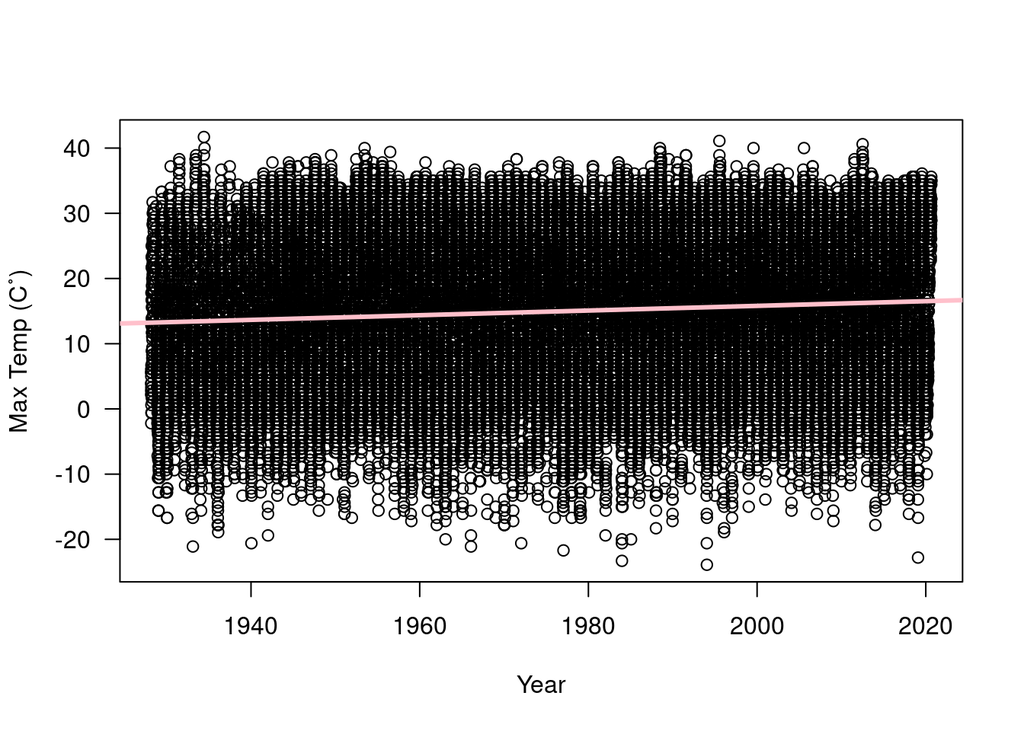

```r
TMAX.lm = lm(TMAX ~ NewDate, data= climate_data)
slopeintercept = coef(TMAX.lm)
plot(TMAX ~ NewDate, data= climate_data, las=1, xlab="Year", ylab="Max Temp (C˚)")
abline(slopeintercept, col="pink", lwd=3)
```

```r
(TMAX.lm.sum = summary(lm(TMAX ~ NewDate, data=climate_data)))
```

```
##
## Call:
## lm(formula = TMAX ~ NewDate, data = climate_data)
##
## Residuals:
##     Min      1Q  Median      3Q     Max
## -39.494 -10.071   0.668  10.416  28.243
##
## Coefficients:
##              Estimate Std. Error t value Pr(>|t|)
## (Intercept) 1.473e+01  6.806e-02  216.46   <2e-16 ***
## NewDate     9.811e-05  6.977e-06   14.06   <2e-16 ***
## ---
## Signif. codes:  0 '***' 0.001 '**' 0.01 '*' 0.05 '.' 0.1 ' ' 1
##
## Residual standard error: 11.93 on 32371 degrees of freedom
##   (22 observations deleted due to missingness)
## Multiple R-squared:  0.006071,   Adjusted R-squared:  0.00604
## F-statistic: 197.7 on 1 and 32371 DF,  p-value: < 2.2e-16
```

```r
climate_data$Month = format(as.Date(climate_data$NewDate), format = "%m")
climate_data$Year = format(climate_data$NewDate, format="%Y")
MonthlyTMAXMean = aggregate(TMAX ~ Month + Year, climate_data, mean)
MonthlyTMAXMean$YEAR = as.numeric(MonthlyTMAXMean$Year)
MonthlyTMAXMean$MONTH = as.numeric(MonthlyTMAXMean$Month)
str(MonthlyTMAXMean)
```

```
## 'data.frame':    1081 obs. of  5 variables:
##  $ Month: chr  "02" "03" "04" "05" ...
##  $ Year : chr  "1928" "1928" "1928" "1928" ...
##  $ TMAX : num  3.9 7.12 12.04 21.19 22.72 ...
##  $ YEAR : num  1928 1928 1928 1928 1928 ...
##  $ MONTH: num  2 3 4 5 6 7 10 11 12 1 ...
```

```r
summary(TMAX.lm)
```

```
##
## Call:
## lm(formula = TMAX ~ NewDate, data = climate_data)
##
## Residuals:
##     Min      1Q  Median      3Q     Max
## -39.494 -10.071   0.668  10.416  28.243
##
## Coefficients:
##              Estimate Std. Error t value Pr(>|t|)
## (Intercept) 1.473e+01  6.806e-02  216.46   <2e-16 ***
## NewDate     9.811e-05  6.977e-06   14.06   <2e-16 ***
## ---
## Signif. codes:  0 '***' 0.001 '**' 0.01 '*' 0.05 '.' 0.1 ' ' 1
##
## Residual standard error: 11.93 on 32371 degrees of freedom
##   (22 observations deleted due to missingness)
## Multiple R-squared:  0.006071,   Adjusted R-squared:  0.00604
## F-statistic: 197.7 on 1 and 32371 DF,  p-value: < 2.2e-16
```

####For this graph of daily temperatures across the years, the probability value is <2e-16. This tiny number is so close to zero, that we can reject the null hypothesis (the assumption that the slope is zero, or that there is not an upward trend) and safely assume that the coefficient of maximum temperature by year has a slope that is not zero. If the p value were closer to one, there would be a greater chance of variation from the model I have created.

## Month by Month Analysis

```r
plot(TMAX~YEAR, data=MonthlyTMAXMean[MonthlyTMAXMean$Month=="05",],
ty='l', xlab="Year", ylab="Max Temp (C˚)", xlim=c(1950, 2020))
May.lm <- lm(TMAX~YEAR, data=MonthlyTMAXMean[MonthlyTMAXMean$Month=="05",])
summary(May.lm)
```

```
##
## Call:
## lm(formula = TMAX ~ YEAR, data = MonthlyTMAXMean[MonthlyTMAXMean$Month ==
##     "05", ])
##
## Residuals:
##     Min      1Q  Median      3Q     Max
## -4.7125 -1.6277 -0.0852  1.8202  5.8190
##
## Coefficients:
##              Estimate Std. Error t value Pr(>|t|)
## (Intercept)  3.848563  17.754154   0.217    0.829
## YEAR         0.008927   0.008993   0.993    0.324
##
## Residual standard error: 2.328 on 91 degrees of freedom
## Multiple R-squared:  0.01071,    Adjusted R-squared:  -0.0001595
## F-statistic: 0.9853 on 1 and 91 DF,  p-value: 0.3235
```

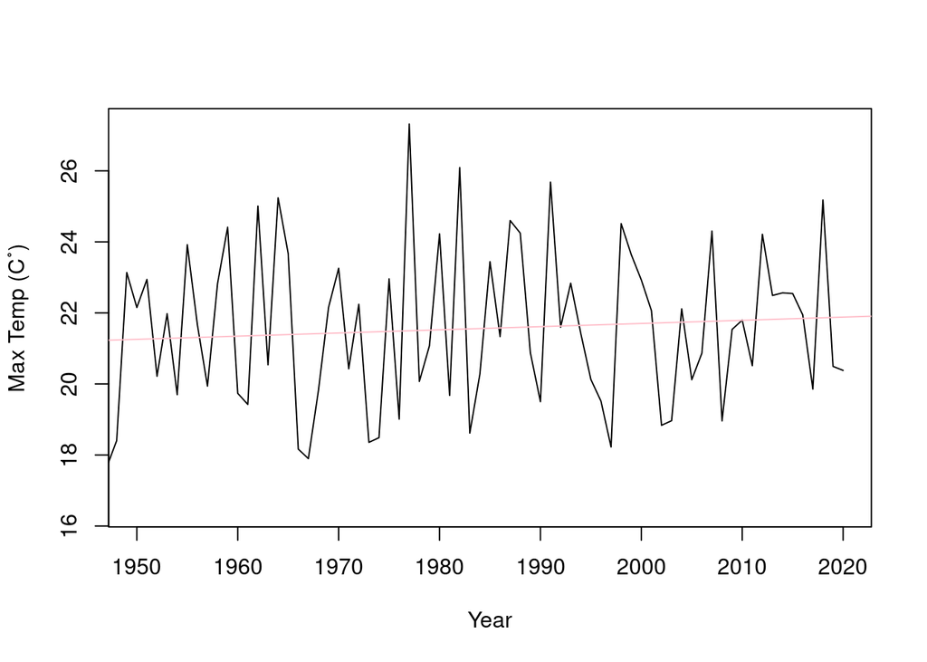

```r
abline(coef(May.lm), col="pink")
```

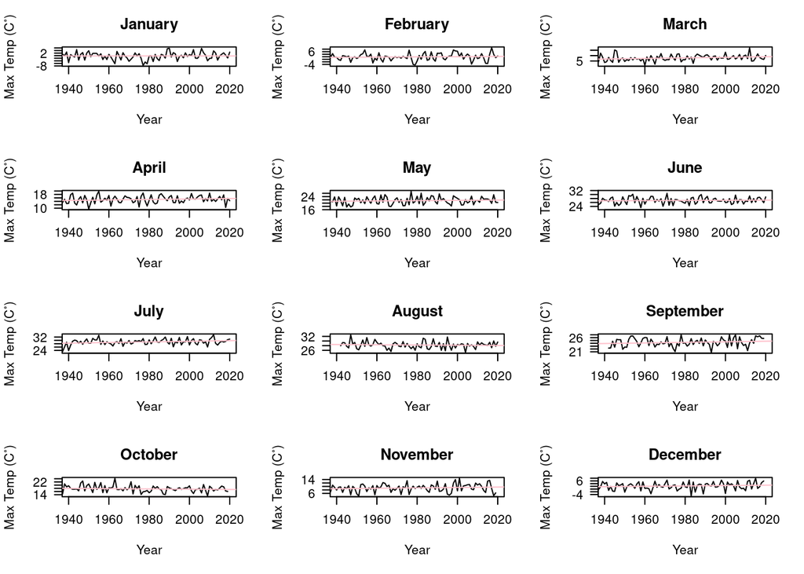

```r
Months = c("January", "February", "March", "April",
"May", "June", "July", "August", "September", "October",
"November", "December")
par(mfrow = c(4, 3), mar = c(5, 4, 3, 2) + 0.1)
TMAXresult <- NA
for (i in 1:12) {
plot(TMAX ~ YEAR, data = MonthlyTMAXMean[MonthlyTMAXMean$MONTH ==
i, ], ty = "l", las = 1, xlab="Year", ylab="Max Temp (C˚)", xlim = c(1940, 2020),
main = Months[i])
Month.lm <- lm(TMAX ~ YEAR, data = MonthlyTMAXMean[MonthlyTMAXMean$MONTH ==
i, ])
summary(Month.lm)
abline(coef(Month.lm), col = "pink")
TMAXresult <- rbind(TMAXresult, cbind(Months[i],
round(coef(Month.lm)[2], 4), round(summary(Month.lm)$coefficients[2,
4], 4), round(summary(Month.lm)$r.squared,
3)))
}
```